# Explore climate-production relationships

## Links between climate and maple syrup production

Maple syrup production is intrinsically linked to climate due to known biophysical processes that result in positive stem pressures after freeze-thaw cycles [@REF]. Several previous studies showed general links between preceding meteorological conditions and syrup production [@REF], as well as the underlying production volume and sugar content [@REF].

We will explore the climatic relationships between production data from the *Producteurs et Productrices Acéricole du Québec* (PPAQ) at the municipal scale for the 2005 to 2021 period and climate data simulated for each producing municipality. We simulated the following climate variables using BioSIM [@REF] for every day from 2004 to 2021:

- Minimum, mean and maximum temperature
- Total rainfall, snowfall, and precipitation
- Mean snow cover
- Mean relative humidity
- Mean wind direction and speed (at 2 and 10 m)
- Total down-welling shortwave radiation
- Mean atmospheric pressure

### Biologically meaningful variables

Let’s start with looking at the climate space we are covering.

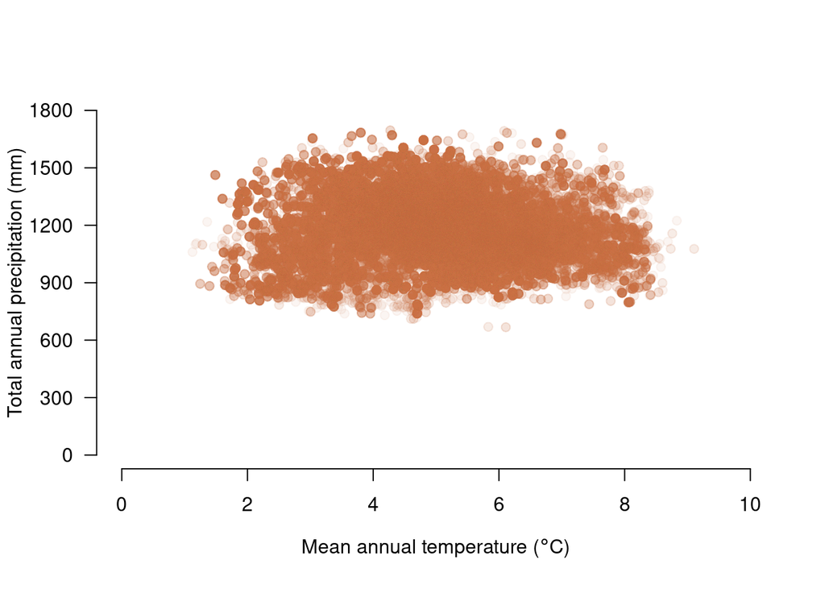

Next, we can look at any relationship between mean annual temperature and total annual precipitation versus production per tap ($L \, tap^{-1}$).

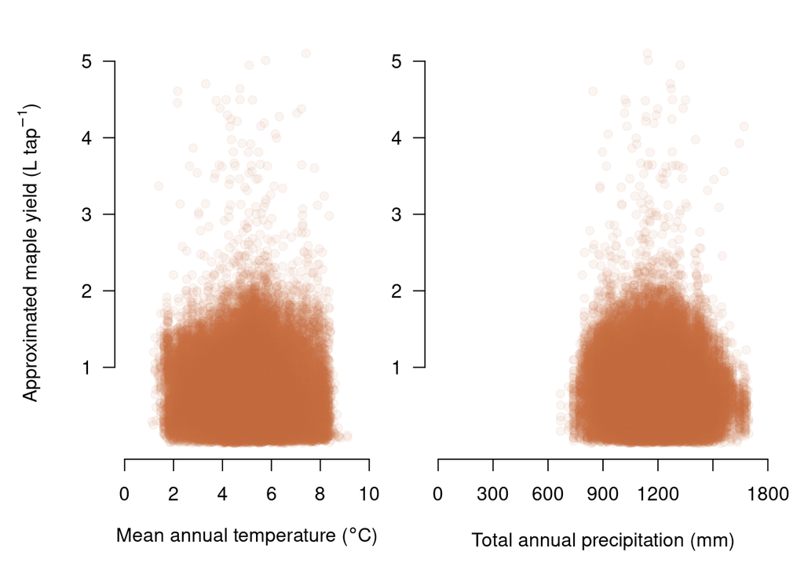